# Generative Models

**Autumn 2024**

## Assignment 1

*Authored by Arip Asadulaev & Manh Lab*

*Adapted by Alexander Panfilov*

The assignment is split into two parts: at first, you will implement classical GAN for the MNIST dataset, and after, you will enhance your results with DCGAN and the CIFAR dataset.

Good luck!

## 1. GAN

*Source: [Goodfellow, Ian J., et al. "Generative Adversarial Networks." arXiv preprint arXiv:1406.2661 (2014)](https://arxiv.org/pdf/1406.2661.pdf).*

In 2014, Ian Goodfellow and his colleagues at the University of Montreal published a stunning paper introducing the world to GANs, or generative adversarial networks. The models play two distinct (literally, adversarial) roles. Given some real data set $\mathcal{X}$, $G$ is the generator, trying to create fake data that looks just like the genuine data, while $D$ is the discriminator, getting data from either the real set or $G$ and labeling the difference.

Goodfellow’s metaphor (and a fine one it is) was that $G$ was like a team of forgers trying to match real paintings with their output, while $D$ was the team of detectives trying to tell the difference. (Except in this case, the forgers $G$ never get to see the original data — only the judgments of $D$. They’re like blind forgers.)

[figure not shown]

[output not shown]

In this part, we are going to implement classical GAN. You can find a rough plan on how to do it below; however, it is not mandatory to stick with it precisely but one might expect some questions related to the listed steps. Feel free to adapt provided code!

- Define the parameters
- Load the data (with transforms and normalization)
- Denormalize for visual inspection of samples
- Define the Discriminator network, the Generator network
- Study the activation function: Leaky ReLU
- Explain the output activation function: Tanh, Sigmoid
- Look at some sample outputs
- Define losses, optimizers and helper functions for training
  - For Discriminator
  - For Generator
- Train the model
- Save intermediate generated images to file
- Look at some outputs
- Save the models

### Imports

```python
import os



import matplotlib.pyplot as plt

import numpy as np

import torch

import torch.nn as nn

import torch.nn.functional as F

from PIL import Image

from torchvision import transforms

from torchvision.datasets import CIFAR10, MNIST

from torch.utils.data import Dataset, DataLoader

from torchvision.transforms import Compose, Normalize, ToTensor

from torchvision.utils import save_image

from sklearn.preprocessing import MinMaxScaler

import torch.optim as optim



%matplotlib inline

plt.style.use("ggplot")
```

### Define parameters & data loading

```python
hidden_size = 256

batch_size = 100

LR = 0.0002

num_epochs = 300

sample_dir = "./continue_exp"

latent_size = 64  # input random input vector latent

image_size = 784  # 28*28 flatten

device = "cuda" if torch.cuda.is_available() else "cpu"



if not os.path.exists(sample_dir):

    os.makedirs(sample_dir)

## Define the dataset

mnist_dataset = MNIST(

    root="data",

    train=True,

    download=True,

    transform=Compose([ToTensor(), Normalize(mean=(0.5,), std=(0.5,))]),

)
```

```python
mnist_dataset.data.shape
```

```
torch.Size([60000, 28, 28])
```

```
Label:  5
```

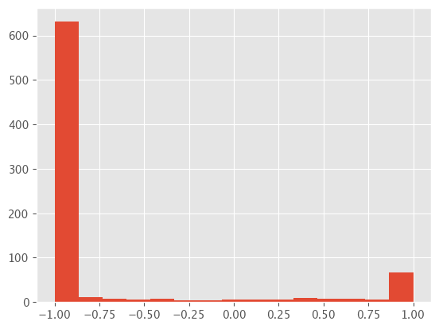

```python
img, label = mnist_dataset[0]

print("Label: ", label)

plt.hist(img[:, :, :].flatten(), bins=15)
```

```python
# denormalization image from range (-1)-1 to range 0-1 to display it

def denorm(x):

    x = x.squeeze(1)



    norm = torch.zeros_like(x)



    for i in range(x.size(0)):

        image = x[i].detach().cpu().numpy()

        scaler = MinMaxScaler()

        image = image.reshape(28, 28)

        scaler.fit(image)

        norm_image = scaler.transform(image)

        norm[i] = torch.tensor(norm_image).to(x.device)



    norm = norm.unsqueeze(1)



    return norm



denorm_img = denorm(img)
```

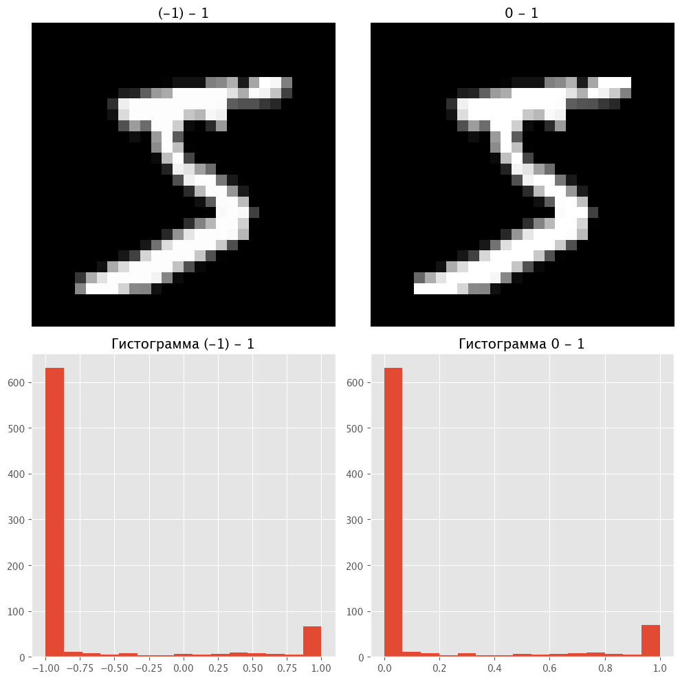

```python
def disply (img, denorm_img):

    img = img.squeeze(0)

    denorm_img = denorm_img.squeeze(0)



    fig, axes = plt.subplots(2, 2, figsize=(10, 10))



    # Отображение первого изображения

    axes[0, 0].imshow(img, cmap='gray')

    axes[0, 0].axis('off')

    axes[0, 0].set_title('(-1) - 1')



    # Отображение второго изображения

    axes[0, 1].imshow(denorm_img, cmap='gray')

    axes[0, 1].axis('off')

    axes[0, 1].set_title('0 - 1')



    # Отображение гистограммы для первого изображения

    axes[1, 0].hist(img.flatten(), bins=15)

    axes[1, 0].set_title('Гистограмма (-1) - 1')



    # Отображение гистограммы для второго изображения

    axes[1, 1].hist(denorm_img.flatten(), bins=15)

    axes[1, 1].set_title('Гистограмма 0 - 1')



    plt.tight_layout()

    plt.show()



disply(img[0], denorm_img[0])
```

```python
type(mnist_dataset)
```

```
torchvision.datasets.mnist.MNIST
```

```python
# define the dataloader

dataloader = DataLoader(mnist_dataset, batch_size=batch_size, shuffle=True)

for data, targets in dataloader:

    print(data.shape)
```

[output not shown]

[output cut: 545 more lines]

[output not shown]

### GAN implementation

GAN consists of two deep networks, a generator ($G$) and a discriminator ($D$). The generator creates images before learning it. Since the discriminator is a binary classification model, we can use the binary cross-entropy loss function to quantify how well it can distinguish between real and generated images.

```python
class Generator(nn.Module):

    def __init__(self, latent_size, image_size, hidden_size):

        super(Generator, self).__init__()

        ## set a linear layer with input size is latent_size and output size is hidden_size

        self.frst = nn.Linear(latent_size, hidden_size)

        # set a linear layer with input size is hidden_size and output size is hidden_size

        self.scnd = nn.Linear(hidden_size, hidden_size)

        # set a linear layer with input size is hidden_size and output size is image_size

        self.thrd = nn.Linear(hidden_size, image_size)



    def forward(self, x):

        # forward x -> linear1 -> relu -> linear2 -> relu -> linear3 -> tanh

        x = self.frst(x)

        x = F.relu(x)

        x = self.scnd(x)

        x = F.relu(x)

        x = self.thrd(x)

        x = torch.tanh(x)



        return x





class Discriminator(nn.Module):

    def __init__(self, image_size, hidden_size):

        super(Discriminator, self).__init__()

        ## set a linear layer with input size is image_size and output size is hidden_size

        self.frst = nn.Linear(image_size, hidden_size)

        # set a linear layer with input size is hidden_size and output size is hidden_size

        self.scnd = nn.Linear(hidden_size, hidden_size)

        # set a linear layer with input size is hidden_size and output size is 1

        self.thrd = nn.Linear(hidden_size, 1)

        self.drop = nn.Dropout(0.3)



    def forward(self, x):

        # forward x -> linear1 -> relu -> linear2 -> relu -> linear3 -> sigmoid

        x = self.frst(x)

        x = F.relu(x)

        x = self.drop(x)

        x = self.scnd(x)

        x = F.relu(x)

        x = self.drop(x)

        x = self.thrd(x)

        x = torch.sigmoid(x)



        return x
```

### Create the Generator and Discriminator

```python
# create new Generator model



# G = Generator...

G = Generator(latent_size, image_size, hidden_size)

# create new Discriminator model



# D = Discriminator...

D = Discriminator(image_size, hidden_size)
```

```python
# show the output of model

y = D(torch.randn(2, image_size))

y
```

```
tensor([[0.4690],
        [0.5037]], grad_fn=<SigmoidBackward0>)
```

```python
# define the criterion is nn.BCELoss()

def criterion(score, labels):

    criterion = nn.BCELoss()



    return criterion(score, labels)



## Define the optimizer for generator and discrimator

def optimazer(O, LR = 0.0001):

    optimizer = optim.Adam(O.parameters(), lr=LR)



    return optimizer



G_optimizer = optimazer(G)

D_optimizer = optimazer(D)
```

```python
y = D(torch.randn(2, image_size))
```

Discriminator Training

```python
def reset_grad(optimizer):

    ## reset gradient for optimizer of generator and discrimator

    optimizer.zero_grad()



    return optimizer



def train_discriminator(D_model, G_model, images, D_optimizer):

    # Create the labels which are later used as input for the BCE loss

    real_labels = torch.ones(batch_size, 1).to(device)

    fake_labels = torch.zeros(batch_size, 1).to(device)





    outputs = D_model(images)

    # Loss for real images

    real_score = outputs

    real_loss = criterion(real_score, real_labels)



    # Loss for fake images

    z = torch.randn(batch_size, latent_size).to(device)

    fake_images = G_model(z)

    outputs = D_model(fake_images)



    fake_score = outputs

    fake_loss = criterion(fake_score, fake_labels)



    # Sum losses

    d_loss = real_loss + fake_loss



    # Reset gradients

    D_optimizer.zero_grad()



    # Compute gradients

    d_loss.backward()



    # Adjust the parameters using backprop

    D_optimizer.step()



    return d_loss, real_score, fake_score
```

Generator Training

```python
def train_generator(G_model, D_model, G_optimizer):

    # Generate fake images and calculate loss

    # z = torch.randn(batch_size, latent_size).to(device)

    z = torch.Tensor(np.random.normal(0, 1, (batch_size, latent_size))).to(device)

    fake_images = G_model(z)



    labels = torch.ones(batch_size, 1).to(device)

    # calculate the generator loss

    outputs = D_model(fake_images).view(-1, 1)

    g_loss = criterion(outputs, labels)



    # Reset gradients

    G_optimizer.zero_grad()



    # Backprop and optimize

    g_loss.backward()



    G_optimizer.step()



    return g_loss, fake_images
```

### Start the training proccess

```python
# function to save the sample output of generator

def save_fake_images_mnist(G_model, index):

    # sample_vectors = torch.randn(batch_size, latent_size).to(device)

    sample_vectors = torch.Tensor(np.random.normal(0, 1, (batch_size, latent_size))).to(

        device

    )

    fake_images = G_model(sample_vectors)

    fake_images = fake_images.reshape(fake_images.size(0), 1, 28, 28)

    fake_fname = "fake_images-{0:0=4d}.png".format(index)

    print("Saving", fake_fname)

    save_image(denorm(fake_images), os.path.join(sample_dir, fake_fname), nrow=10)
```

```python
G.load_state_dict(torch.load("generator.pth", weights_only=True))

D.load_state_dict(torch.load("discriminator.pth", weights_only=True))
```

```
<All keys matched successfully>
```

```python
%%time

total_step = len(dataloader)

d_losses, g_losses, real_scores, fake_scores = [], [], [], []

G.to(device)

D.to(device)



for epoch in range(num_epochs):

    for i, (images, _) in enumerate(dataloader):

        # Load a batch & transform to vectors

        images = images.reshape(batch_size, -1).to(device)



        # Train the discriminator

        d_loss, real_score, fake_score = train_discriminator(D, G, images, D_optimizer)



        # Train the generator

        g_loss, fake_images = train_generator(G, D, G_optimizer)



        # Inspect the losses

        if (i + 1) % 200 == 0:

            d_losses.append(d_loss.item())

            g_losses.append(g_loss.item())

            real_scores.append(real_score.mean().item())

            fake_scores.append(fake_score.mean().item())

            print(

                "Epoch [{}/{}], Step [{}/{}], d_loss: {:.4f}, g_loss: {:.4f}, D(x): {:.2f}, D(G(z)): {:.2f}".format(

                    epoch,

                    num_epochs,

                    i + 1,

                    total_step,

                    d_loss.item(),

                    g_loss.item(),

                    real_score.mean().item(),

                    fake_score.mean().item(),

                )

            )

    # Sample and save images

    save_fake_images_mnist(G, epoch + 1)
```

```
Epoch [0/300], Step [200/600], d_loss: 1.3344, g_loss: 0.8978, D(x): 0.55, D(G(z)): 0.47
Epoch [0/300], Step [400/600], d_loss: 1.2623, g_loss: 0.8805, D(x): 0.55, D(G(z)): 0.44
Epoch [0/300], Step [600/600], d_loss: 1.3169, g_loss: 0.8716, D(x): 0.56, D(G(z)): 0.47
Saving fake_images-0001.png
Epoch [1/300], Step [200/600], d_loss: 1.3737, g_loss: 0.8772, D(x): 0.52, D(G(z)): 0.47
Epoch [1/300], Step [400/600], d_loss: 1.2265, g_loss: 0.8677, D(x): 0.57, D(G(z)): 0.44
Epoch [1/300], Step [600/600], d_loss: 1.2590, g_loss: 0.8424, D(x): 0.54, D(G(z)): 0.42
Saving fake_images-0002.png
Epoch [2/300], Step [200/600], d_loss: 1.3002, g_loss: 0.7972, D(x): 0.55, D(G(z)): 0.45
Epoch [2/300], Step [400/600], d_loss: 1.2797, g_loss: 0.7884, D(x): 0.54, D(G(z)): 0.45
Epoch [2/300], Step [600/600], d_loss: 1.3852, g_loss: 0.9543, D(x): 0.54, D(G(z)): 0.47
Saving fake_images-0003.png
Epoch [3/300], Step [200/600], d_loss: 1.2109, g_loss: 0.8808, D(x): 0.56, D(G(z)): 0.43
Epoch [3/300], Step [400/600], d_loss: 1.2595, g_loss: 0.8608, D(x): 0.57, D(G(z)): 0.45
Epoch [3/300], Step [600/600], d_loss: 1.2146, g_loss: 0.8814, D(x): 0.55, D(G(z)): 0.41
Saving fake_images-0004.png
Epoch [4/300], Step [200/600], d_loss: 1.2329, g_loss: 0.8619, D(x): 0.57, D(G(z)): 0.43
Epoch [4/300], Step [400/600], d_loss: 1.2455, g_loss: 0.9051, D(x): 0.55, D(G(z)): 0.43
Epoch [4/300], Step [600/600], d_loss: 1.2047, g_loss: 0.8545, D(x): 0.59, D(G(z)): 0.45
Saving fake_images-0005.png
Epoch [5/300], Step [200/600], d_loss: 1.2254, g_loss: 0.8606, D(x): 0.57, D(G(z)): 0.44
Epoch [5/300], Step [400/600], d_loss: 1.2278, g_loss: 0.9040, D(x): 0.56, D(G(z)): 0.43
Epoch [5/300], Step [600/600], d_loss: 1.2115, g_loss: 0.8385, D(x): 0.58, D(G(z)): 0.45
Saving fake_images-0006.png
Epoch [6/300], Step [200/600], d_loss: 1.3364, g_loss: 0.8453, D(x): 0.56, D(G(z)): 0.47
Epoch [6/300], Step [400/600], d_loss: 1.2578, g_loss: 0.8056, D(x): 0.55, D(G(z)): 0.43
Epoch [6/300], Step [600/600], d_loss: 1.2906, g_loss: 0.8604, D(x): 0.55, D(G(z)): 0.45
Saving fake_images-0007.png
Epoch [7/300], Step [200/600], d_loss: 1.2214, g_loss: 0.8857, D(x): 0.57, D(G(z)): 0.44
Epoch [7/300], Step [400/600], d_loss: 1.2083, g_loss: 0.8261, D(x): 0.60, D(G(z)): 0.46
Epoch [7/300], Step [600/600], d_loss: 1.3133, g_loss: 0.9128, D(x): 0.55, D(G(z)): 0.46
Saving fake_images-0008.png
Epoch [8/300], Step [200/600], d_loss: 1.2597, g_loss: 0.9077, D(x): 0.54, D(G(z)): 0.42
Epoch [8/300], Step [400/600], d_loss: 1.2447, g_loss: 0.8835, D(x): 0.55, D(G(z)): 0.43
Epoch [8/300], Step [600/600], d_loss: 1.1900, g_loss: 0.8108, D(x): 0.60, D(G(z)): 0.45
Saving fake_images-0009.png
Epoch [9/300], Step [200/600], d_loss: 1.2275, g_loss: 0.9234, D(x): 0.56, D(G(z)): 0.43
Epoch [9/300], Step [400/600], d_loss: 1.2673, g_loss: 0.9069, D(x): 0.54, D(G(z)): 0.43
Epoch [9/300], Step [600/600], d_loss: 1.2240, g_loss: 0.8476, D(x): 0.57, D(G(z)): 0.43
Saving fake_images-0010.png
```

[output cut: 1147 more lines]

```
Saving fake_images-0297.png
Epoch [297/300], Step [200/600], d_loss: 1.1375, g_loss: 1.0251, D(x): 0.63, D(G(z)): 0.41
Epoch [297/300], Step [400/600], d_loss: 1.0912, g_loss: 1.0048, D(x): 0.59, D(G(z)): 0.35
Epoch [297/300], Step [600/600], d_loss: 1.2245, g_loss: 1.0610, D(x): 0.58, D(G(z)): 0.39
Saving fake_images-0298.png
Epoch [298/300], Step [200/600], d_loss: 1.1485, g_loss: 1.1643, D(x): 0.60, D(G(z)): 0.37
Epoch [298/300], Step [400/600], d_loss: 0.9974, g_loss: 1.0683, D(x): 0.66, D(G(z)): 0.37
Epoch [298/300], Step [600/600], d_loss: 1.0977, g_loss: 1.0207, D(x): 0.67, D(G(z)): 0.41
Saving fake_images-0299.png
Epoch [299/300], Step [200/600], d_loss: 1.1121, g_loss: 1.2020, D(x): 0.62, D(G(z)): 0.37
Epoch [299/300], Step [400/600], d_loss: 1.0964, g_loss: 1.0847, D(x): 0.66, D(G(z)): 0.42
Epoch [299/300], Step [600/600], d_loss: 1.1714, g_loss: 1.0531, D(x): 0.61, D(G(z)): 0.38
Saving fake_images-0300.png
CPU times: user 4h 6min 19s, sys: 22min 56s, total: 4h 29min 15s
Wall time: 1h 9min 5s
```

```python
torch.save(G.state_dict(), 'generator.pth')  # Сохранение генератора

torch.save(D.state_dict(), 'discriminator.pth')
```

```python
G.state_dict().keys()
```

```
odict_keys(['frst.weight', 'frst.bias', 'scnd.weight', 'scnd.bias', 'thrd.weight', 'thrd.bias'])
```

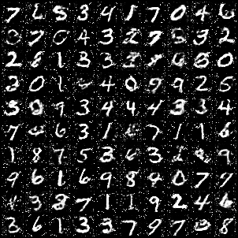

```python
# show output after epochs training
Image.open(os.path.join(sample_dir, "fake_images-0300.png"))
```

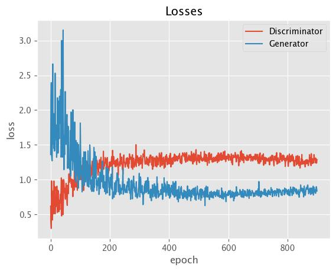

```python
Image.open("/Users/anatoli_vasileva/Desktop/CT-GANs/photo_2024-11-06 15.18.00.jpeg")
```

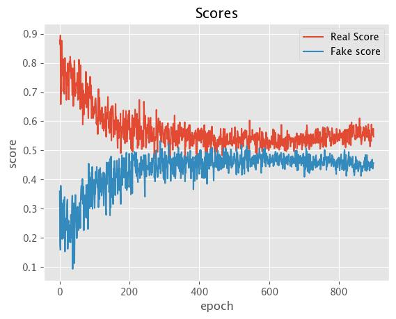

```python
Image.open("/Users/anatoli_vasileva/Desktop/CT-GANs/photo_2024-11-06 15.18.07.jpeg")
```

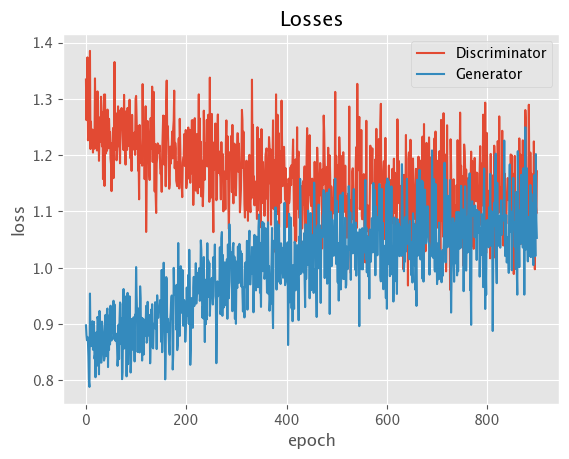

```python
# show the discrimator loss and generator loss

plt.plot(d_losses, "-")

plt.plot(g_losses, "-")

plt.xlabel("epoch")

plt.ylabel("loss")

plt.legend(["Discriminator", "Generator"])

plt.title("Losses");
```

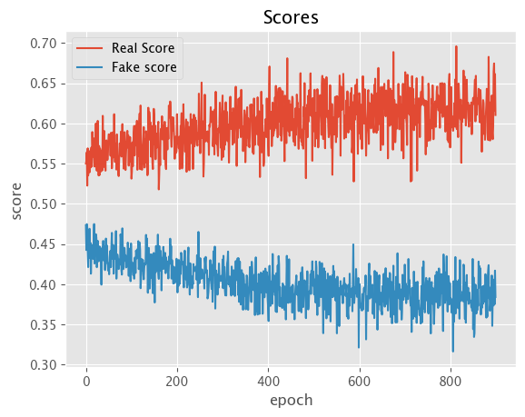

```python
# plot the accuracy of discrimator

plt.plot(real_scores, "-")

plt.plot(fake_scores, "-")

plt.xlabel("epoch")

plt.ylabel("score")

plt.legend(["Real Score", "Fake score"])

plt.title("Scores");
```